# Machine Learning Project

Nasreddine MONTASSER

Friday, February 20, 2015

## Qualitative Activity Recognition

## 1. Presentaion

In the present project we try to predict the manner in with exercices are done

## 2. Loading and Cleaning Training and testing Datasets

Load training and testing datasets from project directory.the first `pml-training.csv`contain 19622 observation of 160 variables. The second `pml-testing.csv`contain 20 observation of 160 variables. Then clean the sets by supressing columns with “NA” .This leads to two new datasets: tab1 and tab 2 containing both 60 columns (variables).

```r
#Training Data Set
############################################
#loading data set from project directory
tt1<-read.csv("pml-training.csv",header=TRUE)

#eliminate columns with most entries are "NA"
tt1cl<-tt1[, !is.na(colSums(tt1 != ""))]
vec1<-apply(tt1cl,2, function(x) all(x != ""))
q1<-which(vec1==FALSE)
tab1<-tt1cl[,-q1]
ncol(tab1)
```

```
## [1] 60
```

```r
# Testing set
############################################sy
#loading data set from project directory
tt2<-read.csv("pml-testing.csv",header=TRUE)

#eliminate columns with most entries are "NA"
tt2cl<-tt2[, !is.na(colSums(tt2 != ""))]
vec2<-apply(tt2cl,2, function(x) all(x != ""))
q2<-which(vec2==FALSE)
tab2<-tt2cl
ncol(tab2)
```

```
## [1] 60
```

## 3. Data Partition - Cross Validation - Random Forest modeling

### 3.1 Data Partition

The initial training data set is divided in trainning and validating datasets

```r
library(caret)
library(randomForest)
#Changing column names
colnames(tab1)<-as.vector(paste0("x", 1:60))

#Data Partition
set.seed(100)
inTrain<-createDataPartition(y=tab1$x1,p=0.7,list=F)
tab1train<-tab1[inTrain,]
tab1valid<-tab1[-inTrain,]

#making formula for random forest Model
xnam <- paste0("x",6:59)
fmla <- as.formula(paste("x60 ~ ", paste(xnam, collapse= "+")))
```

### 3.2 selecting most important features

we appay the randomForest function in the `randomForest` package in a model with all predictors and then find the most importante predictors according the the Gini coefficients finded in the output of the `importance()` function in the package. we choose to use the 8 most important features to learn the random forest model.

```r
#Random forest for features selection
model.rf<-randomForest(fmla, data=tab1train,importance=TRUE,ntree=100)
imp<-round(importance(model.rf),2)
imp<-imp[order(-imp[,7]),]
sel_feat<-row.names(head(imp,8))
```

### 3.3 building predictive model

The predictive model is built using training dataset and cross validation with 10 foldsand 3 repeats. The random forest algorithm determines the model parameters.

```r
#Cross Validation with 3 folds
set.seed(101)
fmla1 <- as.formula(paste("x60 ~ ", paste(sel_feat, collapse= "+")))

#Learning model with Random Forest algorithm
#modrforst<-train(fmla1,data=tab1train,method="rf")
ctrl <- trainControl(method = "repeatedcv", repeats = 3)
modrforst<-train(fmla1,data=tab1train,method="rf",trControl=ctrl)
modrforst$finalModel
```

```
##
## Call:
##  randomForest(x = x, y = y, mtry = param$mtry)
##                Type of random forest: classification
##                      Number of trees: 500
## No. of variables tried at each split: 2
##
##         OOB estimate of  error rate: 0.15%
## Confusion matrix:
##      A    B    C    D    E class.error
## A 3915    1    0    0    0   0.0002554
## B    0 2641    4    1    0   0.0018896
## C    0    5 2400    2    0   0.0029082
## D    0    0    2 2239    1   0.0013381
## E    0    3    0    1 2523   0.0015829
```

```r
print(modrforst)
```

```
## Random Forest
##
## 13738 samples
##    59 predictors
##     5 classes: 'A', 'B', 'C', 'D', 'E'
##
## No pre-processing
## Resampling: Cross-Validated (10 fold, repeated 3 times)
##
## Summary of sample sizes: 12365, 12364, 12364, 12363, 12364, 12363, ...
##
## Resampling results across tuning parameters:
##
##   mtry  Accuracy  Kappa  Accuracy SD  Kappa SD
##   2     1         1      0.001        0.002
##   5     1         1      0.001        0.002
##   8     1         1      0.002        0.003
##
## Accuracy was used to select the optimal model using  the largest value.
## The final value used for the model was mtry = 2.
```

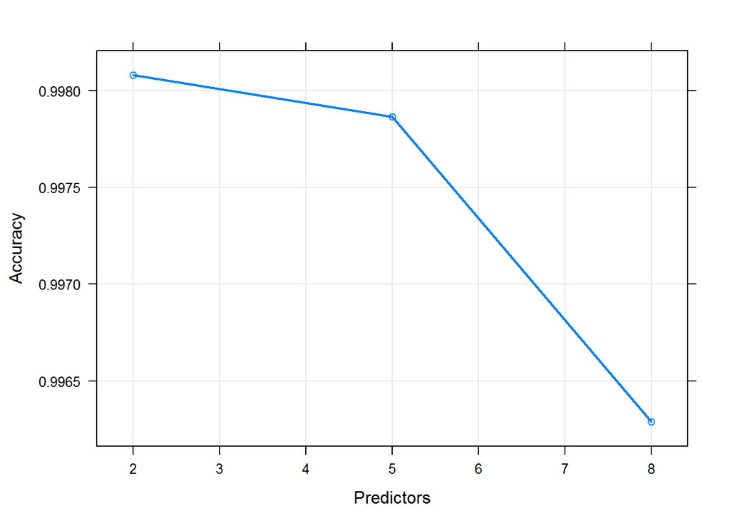

```r
plot(modrforst,log="y",lwd=2,main="",xlab="Predictors",ylab="Accuracy")
```

### 3.3 Applying model to validation dataset

```r
modpred_val<-predict(modrforst,tab1valid)
table(modpred_val,tab1valid$x60)
```

```
##
## modpred_val    A    B    C    D    E
##           A 1664    1    0    0    0
##           B    0 1150    0    0    1
##           C    0    0 1015    1    0
##           D    0    0    0  972    3
##           E    0    0    0    1 1076
```

## 4. Applying model to testing set

```r
#Applying model to test data set
colnames(tab2)<-as.vector(paste0("x", 1:60))
modpred_test<-predict(modrforst,tab2)
modpred_test
```

```
##  [1] B A B A A E D B A A B C B A E E A B B B
## Levels: A B C D E
```

## 5. Out Of Sample error

```r
oos.error<-(1-sum(modpred_val==tab1valid$x60)/length(modpred_val))
oos.error
```

```
## [1] 0.00119
```

the Out Of Sample error is about **0.12%**

## 6. Write Up

```r
pml_write_files<-function(x){
  n<-length(x)
  for(i in 1:n){
    filename<-paste0("problem_id_",i,".txt")
    write.table(x[i],file=filename,quote=FALSE,row.names=FALSE,col.names=FALSE)
  }
}
pml_write_files(modpred_test)
```